# Medidas de tendencia central

[Sofia Garcia Cruz](https://SofíaGarciaCruz.github.io)

Estadística 2022-2, [Facultad de economía](http://www.economia.unam.mx/)

2/3/2022

### 1. ¿Qué son las medidas de tendencia central? 🤔

> Definición: S**on parámetros estadísticos que informan sobre el centro de la distribución de la muestra o población,** sirven para comparar, así como para interpretar los resultados obtenido con relación a los distintos valores observados.

[Economipedia 2022](https://economipedia.com/definiciones/medidas-de-tendencia-central.html)

Para este ejemplo, primero generaremos una serie de **100** números aleatorios entre **1** y **20** mediante la función `sample`. El argumento `TRUE` nos permitirá generar una muestra con remplazo:

```r
numeros <- sample(1:20, 100, TRUE)
numeros
```

```
##   [1] 17  3  1 10  7  6 10 18  7  7  5 13  4 18 11 20 20 11 10 16 18  2 12 18  8
##  [26] 14  4  1  3 20 14 15 17 10 11 14 10 14  2 16  8  6 20 19  8 15  3 20 13  8
##  [51]  5  5 16  8 18  3 16 11  4  1  5 11 11  6 14 11 14  1  9 20 13  3  2 17 16
##  [76] 18  5 11  8 15  7 16 16 15 19  4 17  3 17 19  2 12 10  4 16 17  5 19  8  8
```

### 2. Mediana 📍

> Definición: La mediana es un conjunto es un valor que se encuentra a la mitad de los otros valores, es decir, que al ordenar los número de menor a mayor, éste se encuentra justamente en medio entre los que están por arriba.

> [QuestionPRO 2022](https://www.questionpro.com/blog/es/la-media-la-mediana-y-la-moda/)

Para obtener la **mediana**, podemos ordenar los `numeros` de menor a mayor, **el número que esté en medio de la muestra será la mediana**. Si utilizamos R, se puede hacer el cálculo de la **mediana** con la función `median`:

```r
mediana <- median(numeros)
mediana
```

```
## [1] 11
```

### 3. Media 🧮

> [QuestionPRO 2022](https://www.questionpro.com/blog/es/la-media-la-mediana-y-la-moda/)

$$Media ={\frac {1}{n}}\sum
_{i=1}^{n}a_{i}={\frac {a_{1}+a_{2}+\cdots +a_{n}}{n}}$$

Si usamos R, podemos obtener la media de una muestra si utlilizamos la función **mean**:

```r
media <- mean(numeros)
media
```

```
## [1] 10.88
```

### 4. Moda 📊

> Definición: La moda es el valor que aparece más dentro de un conglomerado. En un grupo puede haber dos modas y se conoce como bimodal, y más de dos modas o multimodal cuando se repiten más de dos valores; se llama amodal cuando en un conglomerado no se repiten los valores.

> [QuestionPRO 2022](https://www.questionpro.com/blog/es/la-media-la-mediana-y-la-moda/)

Podemos saber cuál es la **frecuencia** (número de veces que aparece un elemento en una muestra) de cada número si dibujamos un **histograma** con la función `hist`, **aquel elemento con mayor frecuencia será la moda**:

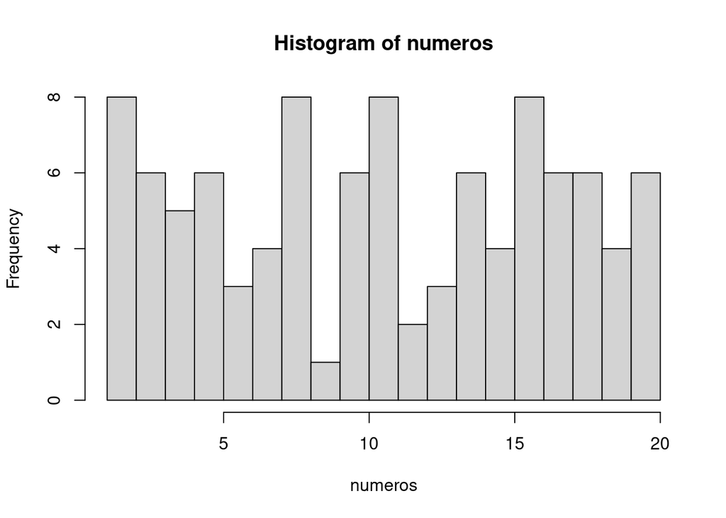

```r
# El argumento breaks nos permite dividir en histograma en las partes que queramos
hist(numeros, breaks = 20)
```

Para obtener un resultado con más precisión, podemos obtener la **moda** si generamos una **tabla de frecuencias** con la función `table` y la función `data.frame`, **aquel elemento con mayor frecuencia será la moda**:

```r
tabla.frecuencias <- data.frame(table(numeros))
tabla.frecuencias
```

```
##    numeros Freq
## 1        1    4
## 2        2    4
## 3        3    6
## 4        4    5
## 5        5    6
## 6        6    3
## 7        7    4
## 8        8    8
## 9        9    1
## 10      10    6
## 11      11    8
## 12      12    2
## 13      13    3
## 14      14    6
## 15      15    4
## 16      16    8
## 17      17    6
## 18      18    6
## 19      19    4
## 20      20    6
```

### 5. Ejercicio 👩‍💻👨‍💻✍

Aplica lo que aprendiste, obten la **mediana**, **media** y **moda** de la siguiente muestra de números:

```r
# Con la función seq, creamos una secuencia de 1 a 10 en intervalos de 0.1 en 0.1
secuencia <- seq(1, 10, 0.1)
muestra <- sample(secuencia, 100, TRUE)
muestra
```

```
##   [1]  9.5  1.5  6.3  4.5  5.8  9.6  5.7  2.2  2.3  6.2  5.4  5.1  7.3  4.9  3.3
##  [16]  6.6  1.6  8.9  8.5  3.3  7.7  6.4  6.1  9.5  5.3  8.8  8.3  4.9  6.5  4.8
##  [31]  6.8  2.3  8.3  1.8  4.1  7.7  1.5  1.0  2.5  5.6  9.2  8.2  1.6  4.7  8.9
##  [46]  2.4  8.7  7.9  8.9  8.4  4.7  8.5  3.6  1.1  4.1  3.6  5.7  9.7  1.4  8.5
##  [61]  6.5  1.2  9.3  3.3  4.4  9.9  8.2  8.2  6.4 10.0  1.4  5.1  5.8  9.6  7.0
##  [76]  5.5  3.4  6.5  4.0  3.0  1.8  1.7  1.1  1.7  8.5 10.0  8.7  1.1  8.0  4.0
##  [91]  6.2  7.1  4.7  2.4  2.8  5.8  3.1  9.5  4.1  3.2
```

##### Mediana

```r
mediana.muestra <- median(muestra)
mediana.muestra
```

```
## [1] 5.65
```

##### Media

```r
media.muestra <- mean(muestra)
media.muestra
```

```
## [1] 5.524
```

##### Moda

```r
tabla.frecuencias <- data.frame(table(muestra))
tabla.frecuencias
```

```
##    muestra Freq
## 1        1    1
## 2      1.1    3
## 3      1.2    1
## 4      1.4    2
## 5      1.5    2
## 6      1.6    2
## 7      1.7    2
## 8      1.8    2
## 9      2.2    1
## 10     2.3    2
## 11     2.4    2
## 12     2.5    1
## 13     2.8    1
## 14       3    1
```

[output cut: 46 more lines]

💻[Código disponible en RStudio Cloud](https://rstudio.cloud/project/3671022)💻